# R Notebook

#No1

```r
library(readxl)
library(psych)
library(GPArotation)
data10.1 <- read_excel("C:/Users/lili/Downloads/Data10Penugasan.xlsx",sheet="Sheet1")
data10.1_new <- data10.1[,-1]
data10.1_new
```

| Miskin | IPM | TPT | Gini |
| --- | --- | --- | --- |
| 10.03 | 70.09 | 2.61 | 0.380 |
| 37.22 | 58.03 | 2.39 | 0.342 |
| 12.44 | 71.69 | 9.68 | 0.432 |
| 24.15 | 68.83 | 6.31 | 0.349 |
| 26.30 | 67.66 | 5.78 | 0.400 |
| 24.57 | 72.19 | 10.42 | 10.420 |
| 36.71 | 56.31 | 0.66 | 0.380 |
| 34.74 | 48.37 | 1.78 | 0.376 |
| 14.26 | 74.19 | 7.51 | 0.339 |
| 19.41 | 61.53 | 3.08 | 0.448 |

[output cut: 19 more lines]

```r
eigen(cor(data10.1_new))
```

```
eigen() decomposition
$values
[1] 2.6448624 0.9562018 0.2476326 0.1513031

$vectors
           [,1]        [,2]       [,3]        [,4]
[1,]  0.5210807 -0.38398472  0.7414383  0.17691771
[2,] -0.5745376  0.14487012  0.3004648  0.74742229
[3,] -0.5729825 -0.07458741  0.5151217 -0.63306980
[4,] -0.2647120 -0.90884823 -0.3076358  0.09634666
```

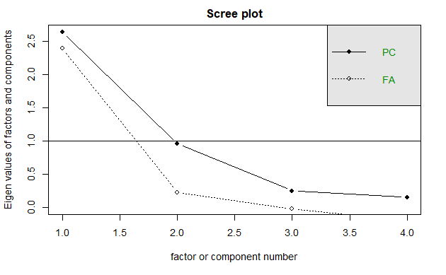

```r
scree(cor(data10.1_new))
```

```r
fa1 <- fa(data10.1_new,nfactors=2,fm="pa",scores=TRUE)
fa1
```

```
Factor Analysis using method =  pa
Call: fa(r = data10.1_new, nfactors = 2, scores = TRUE, fm = "pa")
Standardized loadings (pattern matrix) based upon correlation matrix
```

|  | PA1 | PA2 | h2 | u2 | com |
| --- | --- | --- | --- | --- | --- |
| Miskin | -0.93 | 0.22 | 0.7885336 | 0.21146644 | 1.112743 |
| IPM | 0.88 | 0.08 | 0.8353013 | 0.16469872 | 1.016823 |
| TPT | 0.76 | 0.38 | 0.9001351 | 0.09986487 | 1.459918 |
| Gini | 0.05 | 0.61 | 0.3913122 | 0.60868778 | 1.012320 |

```
                       PA1  PA2
SS loadings           2.29 0.62
Proportion Var        0.57 0.16
Cumulative Var        0.57 0.73
Proportion Explained  0.79 0.21
Cumulative Proportion 0.79 1.00

 With factor correlations of
     PA1  PA2
PA1 1.00 0.32
PA2 0.32 1.00

Mean item complexity =  1.2
Test of the hypothesis that 2 factors are sufficient.

The degrees of freedom for the null model are  6  and the objective function was  2.36 with Chi Square of  60.87
The degrees of freedom for the model are -1  and the objective function was  0

The root mean square of the residuals (RMSR) is  0
The df corrected root mean square of the residuals is  NA

The harmonic number of observations is  29 with the empirical chi square  0  with prob <  NA
The total number of observations was  29  with Likelihood Chi Square =  0  with prob <  NA

Tucker Lewis Index of factoring reliability =  1.116
Fit based upon off diagonal values = 1
Measures of factor score adequacy
                                                   PA1
Correlation of (regression) scores with factors   0.97
Multiple R square of scores with factors          0.93
Minimum correlation of possible factor scores     0.86
                                                   PA2
Correlation of (regression) scores with factors   0.83
Multiple R square of scores with factors          0.68
Minimum correlation of possible factor scores     0.36
```

Berdasarkan analisis faktor tersebut, kedua faktor dapat menjelaskan keragaman data sebesar 73 persen, dengan factor 1 (57 persen) dan factor 2 (16 persen). Variabel- variable yang berkorelasi tinggi dengan factor 1 adalah: presentase penduduk miskin (miskin), indeks pembangunan manusia (IPM), dan tingkat pengangguran terbuka (TPT). Sementara variable yang berkorelasi dengan factor 2 adalah: gini ratio. Skor faktor pada output tersebut, tidak dapat dilihat langsung. Namun system di R sudah menghitungnya, sehingga dapat dibuat biplot nya

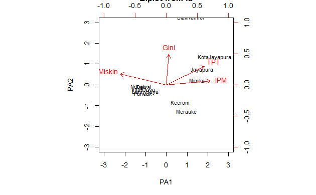

```r
biplot(fa1,labels=data10.1$Kab)
```

Garis merah melambangkan vektor ciri (eigen vector). Semakin panjang eigen vector menunjukkan bahwa semakin besar kontribusi variable tersebut terhadap pembentukan factor. Berdasarkan biplot tersebut, dapat diketahui bahwa variable persentase penduduk miskin (miskin) mempunyai peranan terbesar dalam pembentukan factor 1.

Garis-garis eigen vector yang membentuk sudut semakin lancip menunjukkan bahwa ada korelasi yang tinggi diantara variabel. Pada Gambar biplot tersebut dapat dilihat bahwa variable tingkat pengangguran terbuka (TPT) dengan indeks pembangunan manusia (IPM) berkorelasi sangat tinggi .

Berdasarkan biplot tersebut, dapat dilihat bahwa terdapat pengelompokkan objek. Misalnya,

• Kelompok 1, terdiri dari kota jayapura, jayapura, mimika. Kelompok ini mempunyai karakteristik memiliki TPT dan IPM yang relative lebih tinggi dibanding kabupaten/kota lainnya. Kelompok ini bisa dikatakan kelompok perkotaan maju. • Kelompok 2, terdiri dari kabupaten/kota selain kota jayapura, jayapura, mimika, keerom, merauke. Kelompok ini mempunyai tingkat kemiskinan relative lebih tinggi. Kelompok ini bisa dikatakan kelompok perkotaan dengan tingkat kemiskinan yang tinggi. • Sementara itu ada juga keerom dan merauke yang tidak ikut kedua kelompok tersebut dengan ciri rasio guni rasio yang rendah.

#No2

```r
library(readxl)
data10.2 <- read_excel("C:/Users/lili/Downloads/Data10Penugasan.xlsx",sheet="Sheet2")
data10.2
```

| Pendidikan | Tani_Tambang | Industri | Listrik_Air_Gas | Konstruksi | Dagang | Transport | Akomodasi | Jasa |
| --- | --- | --- | --- | --- | --- | --- | --- | --- |
| No_Ijazah | 127 | 38 | 2 | 8 | 28 | 5 | 5 | 17 |
| SD | 177 | 86 | 1 | 45 | 76 | 13 | 19 | 23 |
| SMP | 54 | 60 | 4 | 32 | 57 | 6 | 23 | 35 |
| SMA | 60 | 50 | 4 | 22 | 96 | 11 | 24 | 62 |
| PT | 6 | 0 | 0 | 2 | 10 | 1 | 1 | 67 |

```r
library(FactoMineR)
library(factoextra)
library(ggplot2)
library(gplots)
```

```r
library(gplots)
data <- as.table(as.matrix(data10.2[,-1]))
rownames(data) <- data10.2$Pendidikan
data
```

```
          Tani_Tambang Industri Listrik_Air_Gas Konstruksi Dagang Transport Akomodasi Jasa
No_Ijazah          127       38               2          8     28         5         5   17
SD                 177       86               1         45     76        13        19   23
SMP                 54       60               4         32     57         6        23   35
SMA                 60       50               4         22     96        11        24   62
PT                   6        0               0          2     10         1         1   67
```

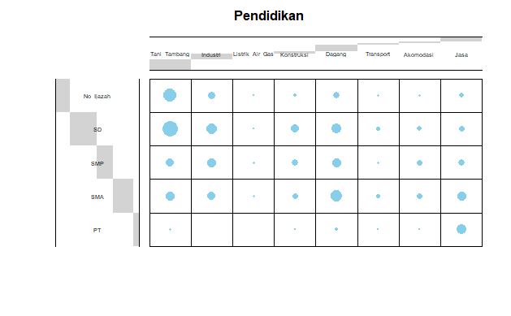

```r
balloonplot(t(data), main ="Pendidikan", xlab ="", ylab="",label = FALSE, show.margins = FALSE,dotsize=4, text.size=0.5)
```

- Pekerjaan tani tambang banyak dilakukan oleh orang berpendidikan rendah (tanpa ijazah atau SD)
- pendidikan SMA lebih banyak bekerja dibidang dagang dan jasa.
- pendidikan SMP lebih banyak bekerja di bidang industri atau dagang
- Orang orang yang melakukan pekerjaan dibidang jasa, semakin besar seiring dengan semakin tingginya pendidikannya

```r
an.ca <- CA(data, graph = FALSE)
print(an.ca)
```

```
**Results of the Correspondence Analysis (CA)**
The row variable has  5  categories; the column variable has 8 categories
The chi square of independence between the two variables is equal to 449.4398 (p-value =  1.615109e-77 ).
*The results are available in the following objects:

   name              description
1  "$eig"            "eigenvalues"
2  "$col"            "results for the columns"
3  "$col$coord"      "coord. for the columns"
4  "$col$cos2"       "cos2 for the columns"
5  "$col$contrib"    "contributions of the columns"
6  "$row"            "results for the rows"
7  "$row$coord"      "coord. for the rows"
8  "$row$cos2"       "cos2 for the rows"
9  "$row$contrib"    "contributions of the rows"
10 "$call"           "summary called parameters"
11 "$call$marge.col" "weights of the columns"
12 "$call$marge.row" "weights of the rows"
```

```r
summary(an.ca)
```

```
Call:
CA(X = data, graph = FALSE)

The chi square of independence between the two variables is equal to 449.4398 (p-value =  1.615109e-77 ).

Eigenvalues
                       Dim.1   Dim.2   Dim.3   Dim.4
Variance               0.244   0.072   0.012   0.004
% of var.             73.532  21.877   3.483   1.108
Cumulative % of var.  73.532  95.409  98.892 100.000

Rows
                  Iner*1000     Dim.1     ctr    cos2     Dim.2     ctr    cos2     Dim.3     ctr
No_Ijazah       |    50.319 |  -0.328   7.505   0.363 |  -0.421  41.461   0.597 |  -0.081   9.548
SD              |    35.072 |  -0.308  12.640   0.878 |  -0.067   2.021   0.042 |   0.063  11.223
SMP             |    20.338 |  -0.006   0.003   0.000 |   0.284  22.266   0.793 |   0.124  26.425
SMA             |    30.472 |   0.197   3.867   0.309 |   0.252  21.192   0.504 |  -0.152  48.796
PT              |   195.000 |   1.699  75.986   0.949 |  -0.384  13.060   0.049 |   0.085   4.007
                   cos2
No_Ijazah         0.022 |
SD                0.037 |
SMP               0.150 |
SMA               0.185 |
PT                0.002 |

Columns
                  Iner*1000     Dim.1     ctr    cos2     Dim.2     ctr    cos2     Dim.3     ctr
Tani_Tambang    |    73.028 |  -0.356  16.278   0.543 |  -0.326  45.860   0.455 |  -0.022   1.345
Industri        |    15.468 |  -0.255   4.610   0.726 |   0.125   3.705   0.174 |   0.086  11.093
Listrik_Air_Gas |     3.470 |  -0.037   0.004   0.003 |   0.417   1.944   0.406 |  -0.181   2.291
Konstruksi      |    13.036 |  -0.166   0.911   0.170 |   0.255   7.189   0.400 |   0.254  44.801
Dagang          |    19.297 |   0.023   0.041   0.005 |   0.273  20.245   0.760 |  -0.146  36.429
Transport       |     1.385 |  -0.102   0.114   0.200 |   0.115   0.481   0.252 |  -0.112   2.864
Akomodasi       |    11.434 |  -0.034   0.025   0.005 |   0.455  15.136   0.959 |   0.009   0.035
Jasa            |   194.083 |   1.124  78.017   0.979 |  -0.162   5.440   0.020 |   0.030   1.143
                   cos2
Tani_Tambang      0.002 |
Industri          0.083 |
Listrik_Air_Gas   0.076 |
Konstruksi        0.397 |
Dagang            0.218 |
Transport         0.239 |
Akomodasi         0.000 |
Jasa              0.001 |
```

Dari output tersebut didapatkan: nilai Chi square yang menunjukkan statistik uji untuk independence test antar kategori baris dan kolom adalah sebesar 449.4398 (p-value =0 ). Nilai Chi square yang tinggi tersebut menunjukkan ada hubungan/ketergantunganantar kategori baris dan kolom.

Terbentuk 4 dimensi, dimensi 1 menjelaskan 73.532% dari total inertia (variasi data), dimensi 2 sebesar 21.877%,dimensi 3 sebesar 3.483% dan dimensi 4 sebesar 1.108%. Namun jika kita menggunakan dua dimensi pertama (dimensi 1 dan 2) saja, total inertia (varians) yang bisa dijelaskan sudah cukup tinggi yaitu sebesar 95.409%.

Output juga menghasilkan skor setiap dimensi untuk kategori baris dan kolom(ini tidak lain adalah titik-titik koordinat). Namun cukup sulit diinterpretasikan. Oleh karena itu perlu digunakan visualisasi grafik.

```r
df1 <- (nrow(data) - 1) * (ncol(data) - 1)
qchisq(1-0.05,df=df1)
```

```
[1] 41.33714
```

Nilai Chi-square tabel pada saat alpha=0.05% dan derajat bebas df=(nr-1)*(nc-1) adalah sebesar 41.33714. Kita lihat nilai Chi-square hitung = 449.4398 > Chi-square tabel. Hal ini menghasilkan keputusan “tolak H0” (antar kategori baris dan kolom independent), artinya ada hubungan antar kategori baris dan kolom

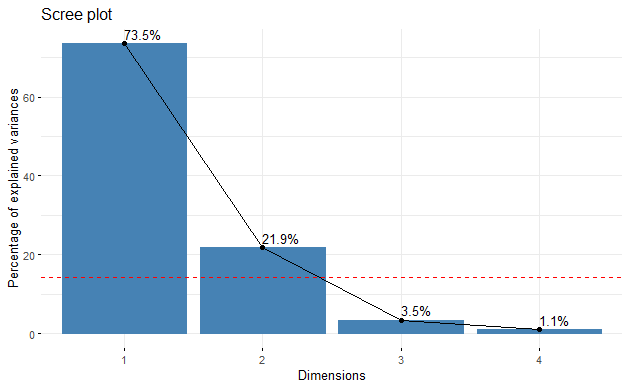

```r
fviz_screeplot(an.ca,addlabels = TRUE) +
geom_hline(yintercept=14.29, linetype=2, color="red")
```

Menurut grafik di atas, cukup digunakan dimensi 1 dan 2. Dimensi 3 dan 4 menjelaskan hanya= 3.5% dan 1.1% dari total inertia yang berada di bawah nilai eigen rata-rata (14.29%) dan terlalu sedikit untuk disimpan dalam analisis lebih lanjut.

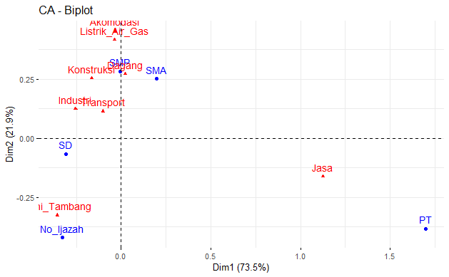

```r
library(Rcpp)
# repel= TRUE untuk menghindari text tumpang tindih(running lambat jika titiknya banyak)
fviz_ca_biplot(an.ca, repel = F)
```

Plot simetris mewakili profil baris dan kolom secara bersamaan dalam ruang bersama. Biplot simetris ini menunjukkan pola umum data. Warna biru adalah kategori untuk baris dan merah untuk kolom. Dalam hal ini, hanya jarak antar titik dalam baris atau jarak antar titik dalam kolom yang dapat diinterpretasikan. Sementara itu, jarak antara item baris dan kolom tidak memiliki makna. Jarak antara titik baris atau titik kolom memberikan ukuran similarity (atau disimilarity). Titik yang berdekatan menunjukkan adanya kesamaan profil

- Pekerjaan akomodasi, kontruksi, dagang, industri, transportasi, listrik air gas banyak dilakukan orang berpendidikan SMP dilanjutkan dengan pendidikan SMA
- Pekerjaan dibidang jasa banyak dilakukan lulusan pergurusan tinggi

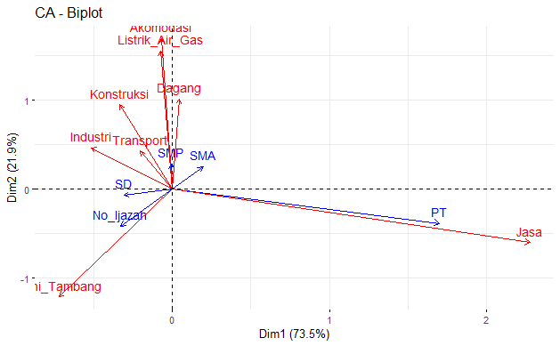

```r
fviz_ca_biplot(an.ca,map ="rowprincipal", arrow = c(TRUE, TRUE),
repel = F)
```

Jika sudut antara dua anak panah (biru dan merah) lancip, maka itu adalah hubungan yang kuat antara baris dan kolom yang bersesuaian. Pada gambar tersebut menunjukkan bahwa - Pekerjaan dibidang jasa berhubungan erat dengan lulusan perguruan tinggi - Sementara pekerjaan tani tambang berhubungan erat dengan masyarakat yang tidak memiliki ijazah

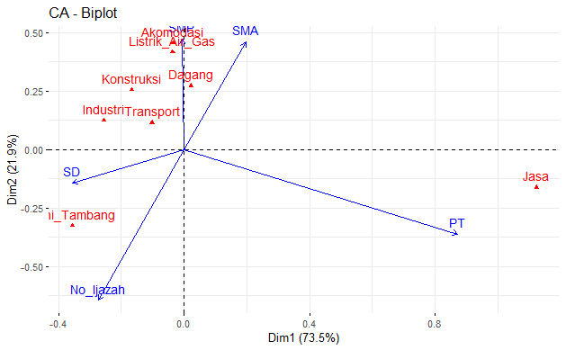

```r
#Biplot kontribusi setiap kategori Baris terhadap pembentukan Dimensi
fviz_ca_biplot(an.ca, map ="colgreen", arrow = c(TRUE, FALSE),
repel = F)
```

• Kategori “PT dan SD” berkontribusi penting dalam pembentukan Dimensi pertama • Kategori “SMP,SMA,No Ijazah” berkontribusi penting dalam Dimensi 2.

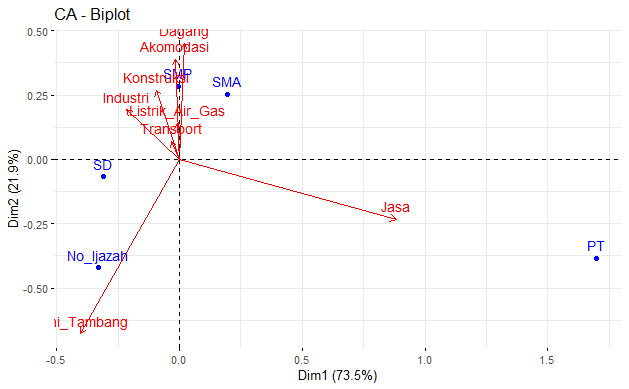

```r
#Biplot kontribusi setiap kategori Kolom terhadap Dimensi
fviz_ca_biplot(an.ca, map ="rowgreen", arrow = c(FALSE, TRUE), repel
= F)
```

```r
deskripsi.dimensi <- dimdesc(an.ca, axes = c(1,2))
deskripsi.dimensi
```

```
$`Dim 1`
$`Dim 1`$row
                 coord
No_Ijazah -0.328378314
SD        -0.308121933
SMP       -0.005726466
SMA        0.197093697
PT         1.698950677

$`Dim 1`$col
                      coord
Tani_Tambang    -0.35619612
Industri        -0.25516251
Konstruksi      -0.16623151
Transport       -0.10215373
Listrik_Air_Gas -0.03673402
Akomodasi       -0.03373645
Dagang           0.02255728
Jasa             1.12422676


$`Dim 2`
$`Dim 2`$row
                coord
No_Ijazah -0.42100051
PT        -0.38417847
SD        -0.06719954
SMA        0.25166018
SMP        0.28422598

$`Dim 2`$col
                     coord
Tani_Tambang    -0.3261061
Jasa            -0.1619271
Transport        0.1146342
Industri         0.1247777
Konstruksi       0.2546482
Dagang           0.2730391
Listrik_Air_Gas  0.4168769
Akomodasi        0.4546324
```

Dengan demikian kita dapat melabeli Dimensi 1 sebagai “Pekerjaan yang didominasi lulusan perguruan tinggi”, sementara Dimensi 2 sebagai “Pekerjaan yang didominasi masyarakat yang tidak menyenyam perguruan tinggi”.